# Exploring Classification Metrics

## Description

In this assignment we created R functions to calculate several different classification metrics as R functions from base R commands. We also verified the functions by checking R package implementations against our output. Lastly, we graphed the output of the classification model

### Dataset

The data set was provided by the professor.

First we must examine the data file provided. On first examination, it looks like the dependent variable class was regressed against several independent variables. The Scored class is the predicted variable, and the scored.probability shows the probability that the scored.class belongs to a class of 1. A further description of the variables is given below:

- *pregnant*: no of times pregnant
- *glucose*: plasma glucose concentration
- *diastolic*: diastolic blod pressure
- *skinfold*: triceps skin fold thickness
- *insulin*: serum insulin test
- *bmi*: body mass index
- *pedigree*: diabetes pedigree function
- *age*: age in years
- *class*: (1: positive for diabetes, 0 negative for diabetes)

(Ref: https://www.kaggle.com/kumargh/pimaindiansdiabetescsv)

| pregnant | glucose | diastolic | skinfold | insulin | bmi | pedigree | age | class | scored.class | scored.probability |
| --- | --- | --- | --- | --- | --- | --- | --- | --- | --- | --- |
| 7 | 124 | 70 | 33 | 215 | 25.5 | 0.161 | 37 | 0 | 0 | 0.3284523 |
| 2 | 122 | 76 | 27 | 200 | 35.9 | 0.483 | 26 | 0 | 0 | 0.2731904 |
| 3 | 107 | 62 | 13 | 48 | 22.9 | 0.678 | 23 | 1 | 0 | 0.1096604 |
| 1 | 91 | 64 | 24 | 0 | 29.2 | 0.192 | 21 | 0 | 0 | 0.0559984 |
| 4 | 83 | 86 | 19 | 0 | 29.3 | 0.317 | 34 | 0 | 0 | 0.1004907 |
| 1 | 100 | 74 | 12 | 46 | 19.5 | 0.149 | 28 | 0 | 0 | 0.0551546 |

## Solution 02

The data set has three key columns we will use:

- *class*: the actual class for the observation
- *scored.class*: the predicted class for the observation (based on a threshold of 0.5)
- *scored.probability*: the predicted probability of success for the observation

> Use the table() function to get the raw confusion matrix for this scored dataset. Make sure you understand the output. In particular, do the rows represent the actual or predicted class? The columns?

Let us look at the actual class and predicted class separately.

Actual class

```r
table(data$class, dnn = "Actual class")  %>% kable()  %>%
  kable_styling()
```

| Actual.class | Freq |
| --- | --- |
| 0 | 124 |
| 1 | 57 |

Predicted class

```r
table(data$scored.class, dnn = "Predicted class")  %>% kable()  %>%
  kable_styling()
```

| Predicted.class | Freq |
| --- | --- |
| 0 | 149 |
| 1 | 32 |

**A quick check on threshold of stored.class and scored.probability**

I’ll investigate whether there is any case where stored.class is 1 and scored.probability is less than 0.5 OR stored.class is not 1 and scored.probability is greater than or equal to 0.5.

```r
checkProb <- function(df) {
   count <- 0
   for(i in 1:nrow(data)) {
      if ( (df$scored.class[i] == 1 & df$scored.probability[i] < 0.5) | (df$scored.class[i] != 1 & df$scored.probability[i] >= 0.5) ) {
         count <- count + 1
      }
   }
   return(count)
}
```

```r
print(paste0("Case count: ", sprintf("%1d", checkProb(data))))
```

```
## [1] "Case count: 0"
```

So, we observe that there are no such cases.

Raw confusion matrix for the data

```r
table(data$scored.class, data$class,
      dnn = c("Predicted", "Actual"))  %>% kable()  %>%
  kable_styling()
```

|  | 0 | 1 |
| --- | --- | --- |
| 0 | 119 | 30 |
| 1 | 5 | 27 |

A confusion matrix shows the number of correct and incorrect predictions made by the model compared to the actual outcomes.

Following the classification laid down in https://developers.google.com/machine-learning/crash-course/classification/true-false-positive-negative,

We can see that:

- TP True Positive Row1Col1: 119 correct predictions were made about class 0 (Actual 0 and Predicted 0)
- TN True Positive Row2Col2: 27 correct predictions were made about class 1 (Actual 1 and Predicted 1)
- FN False Positive Row2Col1: 5 of the observations had an actual value of 0 but predicted as 1.
- FP False Negative Row1Col2: 30 of the observations had an actual value of 1 but predicted as 0

## Solution 03

> Write a function that takes the data set as a dataframe, with actual and predicted classifications identified, and returns the accuracy of the predictions.

$$Accuracy = \frac{TP + TN}{TP + FP + TN + FN}$$
The R function is below:

```r
getAccuracy <- function(df){
   confusion_matrix <- table(df$scored.class, df$class,
                        dnn = c("Predicted", "Actual"))
   TN <- confusion_matrix[2,2]
   FN <- confusion_matrix[2,1]
   FP <- confusion_matrix[1,2]
   TP <- confusion_matrix[1,1]
   Accuracy <- (TP+TN)/(TP+FP+TN+FN)
   #print(paste0("The Accuracy rate is ", sprintf("%1.2f%%", 100*Accuracy)))
   return(Accuracy)
}
```

We run the function on our data and find an accuracy rate of 80.7%.

```r
getAccuracy(data)
```

```
## [1] 0.8066298
```

We can do the same using the caret package and it returns the same result.

```r
acc<-confusionMatrix(table(data$scored.class, data$class))
acc$overall['Accuracy']
```

```
##  Accuracy
## 0.8066298
```

## Solution 04

> Write a function that takes the data set as a dataframe, with actual and predicted classifications identified, and returns the classification error rate of the predictions.

Verify that you get an accuracy and an error rate that sums to one.

$$Classification\ Error\ Rate = \frac{FP + FN}{TP + FP + TN + FN}$$
WE have created the function below to calculate Classification error rate.

```r
getClassError <- function(df){
   confusion_matrix <- table(df$scored.class, df$class,
                        dnn = c("Predicted", "Actual"))
   TN <- confusion_matrix[2,2]
   FN <- confusion_matrix[2,1]
   FP <- confusion_matrix[1,2]
   TP <- confusion_matrix[1,1]
   ClassificationErrorRate <- (FP+FN)/(TP+FP+TN+FN)
   return(ClassificationErrorRate)

}
```

We run it on our data

```r
getClassError(data)
```

```
## [1] 0.1933702
```

The Accuracy and Error rates sum to 1.

```r
print(paste0("The sum is ", (getClassError(data) + getAccuracy(data))))
```

```
## [1] "The sum is 1"
```

## Solution 05

> Write a function that takes the data set as a dataframe, with actual and predicted classifications identified, and returns the precision of the predictions.

$$Precision=\frac{TP}{TP+FP}$$
The R function for Precision, also known as Positive Predictive value (PPV), is as follows:

```r
getPrecision <- function(df){
   confusion_matrix <- table(df$scored.class, df$class,
                        dnn = c("Predicted", "Actual"))
   TN <- confusion_matrix[2,2]
   FN <- confusion_matrix[2,1]
   FP <- confusion_matrix[1,2]
   TP <- confusion_matrix[1,1]
   Precision <- (TP)/(TP+FP)
   return(Precision)
}
```

Running it on our data

```r
getPrecision(data)
```

```
## [1] 0.7986577
```

Verification using caret:

```r
posPredValue(table(data$scored.class, data$class))
```

```
## [1] 0.7986577
```

## Solution 06

> Write a function that takes the data set as a dataframe, with actual and predicted classifications identified, and returns the sensitivity of the predictions. Sensitivity is also known as recall.

$$Sensitivity=\frac{TP}{TP+FN}$$

Sensitivity is also known as Recall, Hit rate or True Positive Rate (TPR).

The R function to calculate recall is as follows:

```r
getSensitivity <- function(df){
   confusion_matrix <- table(df$scored.class, df$class,
                        dnn = c("Predicted", "Actual"))
   TN <- confusion_matrix[2,2]
   FN <- confusion_matrix[2,1]
   FP <- confusion_matrix[1,2]
   TP <- confusion_matrix[1,1]
   Sensitivity <- (TP)/(TP+FN)
   return(Sensitivity)
}
```

Running it on our data

```r
getSensitivity(data)
```

```
## [1] 0.9596774
```

Verification using caret

```r
sensitivity(table(data$scored.class, data$class))
```

```
## [1] 0.9596774
```

## Solution 07

> Write a function that takes the data set as a dataframe, with actual and predicted classifications identified, and returns the specificity of the predictions.

$$Specificity=\frac{TN}{TN+FP}$$

Specificity is also called selectivity or True Negative Rate (TNR). The R function to calculate this is as follows:

```r
getSpecificity <- function(df){
   confusion_matrix <- table(df$scored.class, df$class,
                        dnn = c("Predicted", "Actual"))
   TN <- confusion_matrix[2,2]
   FN <- confusion_matrix[2,1]
   FP <- confusion_matrix[1,2]
   TP <- confusion_matrix[1,1]
   Specificity <- (TN)/(TN+FP)
   return(Specificity)
}
```

Running on our data

```r
getSpecificity(data)
```

```
## [1] 0.4736842
```

Verification using caret:

```r
specificity(table(data$scored.class, data$class))
```

```
## [1] 0.4736842
```

## Solution 08

> Write a function that takes the data set as a dataframe, with actual and predicted classifications identified, and returns the F1 score of the predictions.

$$F1\ Score=\frac{2*Precision*Sensitivity}{Precision + Sensitivity}$$

F1 Score is the harmonic mean of precision and sensitivity. The highest possible value of F1 is 1, indicating perfect precision and recall, and the lowest possible value is 0, if either the precision or the recall is zero.

The R function is below:

```r
getF1Score <- function(df){
   confusion_matrix <- table(df$scored.class, df$class,
                        dnn = c("Predicted", "Actual"))
   TN <- confusion_matrix[2,2]
   FN <- confusion_matrix[2,1]
   FP <- confusion_matrix[1,2]
   TP <- confusion_matrix[1,1]
   Sensitivity <- (TP)/(TP+FN)
   Precision <- (TP)/(TP+FP)
   F1Score <- (2 * Precision * Sensitivity)/(Precision + Sensitivity)
   return(F1Score)
}
```

Running on our data

```r
getF1Score(data)
```

```
## [1] 0.8717949
```

Verification using caret:

```r
acc$byClass['F1']
```

```
##        F1
## 0.8717949
```

## Solution 09

> Before we move on, let’s consider a question that was asked: What are the bounds on the F1 score? Show that the F1 score will always be between 0 and 1. (Hint: If 0 < a < 1 and 0 < b < 1 then a b < a)

Precision values can range from 0 to 1

$$0\ge P\ge 1$$

Sensitivity values can also range from 0 to 1

$$0\ge S\ge 1$$
Using If 0 < a < 1 and 0 < b < 1 then a b < a, we get

$$PS\le S$$
$$PS\le P$$
This implies that

$$0\le PS\le P\le 1$$
$$0\le PS\le S\le 1$$

## Solution 10

> Write a function that generates an ROC curve from a data set with a true classification column (class in our example) and a probability column (scored.probability in our example). Your function should return a list that includes the plot of the ROC curve and a vector that contains the calculated area under the curve (AUC). Note that I recommend using a sequence of thresholds ranging from 0 to 1 at 0.01 intervals.

The function is given below

```r
Roc_function<- function(d){ #d stands for dataframe that you will pass in function
   #Create a count
   temp <- table(d[ ,'class'], d[ ,"scored.probability"])
   #Calculate frequency
   allPos <- sum(data$class == 1, na.rm=TRUE)
   allNeg <- sum(data$class == 0, na.rm=TRUE)
   #Set threshold
   threshold <- seq(0,1,0.01)
   #Calculating probability for threshold
   x <- c()
   y <- c()
   for (i in 1:length(threshold)) {
      TP <- sum(data$scored.probability >= threshold[i] & data$class == 1, na.rm=TRUE)
      TN <- sum(data$scored.probability < threshold[i] & data$class == 0, na.rm=TRUE)
      y[i] <- TP / allPos
      x[i] <- 1-TN / allNeg
   }

   rocPlot <- plot(x,y,type = "s", xlim=c(-0.5,1.5),
                 main = "ROC Curve from function",
                 xlab = "1-Specificity",
                 ylab = "Sensitivity")
   fPlot <- abline(0,1); fPlot

   xd <- c(0, abs(diff(x)))
   fAuc <- sum(xd*y); fAuc

   print(paste0("Area under the curve: ", fAuc))
}
```

Let us call the function on our data

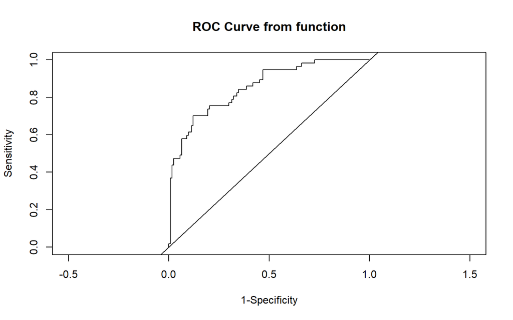

```
## [1] "Area under the curve: 0.843803056027165"
```

```r
Roc_function(data)
```

## Solution 11

> Use your created R functions and the provided classification output data set to produce all of the classification metrics discussed above.

The classification metrics can be found in the table below:

```r
df1 <- c(getAccuracy(data),
         getClassError(data),
         getPrecision(data),
         getSensitivity(data),
         getSpecificity(data),
         getF1Score(data))
names(df1) <- c("Accuracy", "Classification Error", "Precision",
                "Sensitivity", "Specificity", "F1 Score")
df1<-as.data.frame(df1)
names(df1)[1]<-'Scores'
kable(df1) %>% kable_classic("hover", full_width = F, html_font = "Cambria")
```

|  | Scores |
| --- | --- |
| Accuracy | 0.8066298 |
| Classification Error | 0.1933702 |
| Precision | 0.7986577 |
| Sensitivity | 0.9596774 |
| Specificity | 0.4736842 |
| F1 Score | 0.8717949 |

## Solution 12

> Investigate the caret package. In particular, consider the functions confusionMatrix, sensitivity, and specificity. Apply the functions to the data set. How do the results compare with your own functions?

We have already tested out our calculations with the caret package for each part. We will show it here. We find that the values we calculated using our R functions are exactly the same as those calculated by the caret package.

```r
df2<- confusionMatrix(data = as.factor(data$scored.class),
reference = as.factor(data$class),
positive = '0')
df2
```

```
## Confusion Matrix and Statistics
##
##           Reference
## Prediction   0   1
##          0 119  30
##          1   5  27
##
##                Accuracy : 0.8066
##                  95% CI : (0.7415, 0.8615)
##     No Information Rate : 0.6851
##     P-Value [Acc > NIR] : 0.0001712
##
##                   Kappa : 0.4916
##
##  Mcnemar's Test P-Value : 4.976e-05
##
##             Sensitivity : 0.9597
##             Specificity : 0.4737
##          Pos Pred Value : 0.7987
##          Neg Pred Value : 0.8438
##              Prevalence : 0.6851
##          Detection Rate : 0.6575
##    Detection Prevalence : 0.8232
##       Balanced Accuracy : 0.7167
##
##        'Positive' Class : 0
##
```

## Solution 13

> Investigate the pROC package. Use it to generate an ROC curve for the data set. How do the results compare with your own functions?

```r
#Generate the function
rCurve <- roc(data$class, data$scored.probability, levels=c(1,0), direction=">")
```

Area under the curve

```r
auc(rCurve)
```

```
## Area under the curve: 0.8503
```

Confidence interval for the curve

```r
ci(rCurve)
```

```
## 95% CI: 0.7905-0.9101 (DeLong)
```

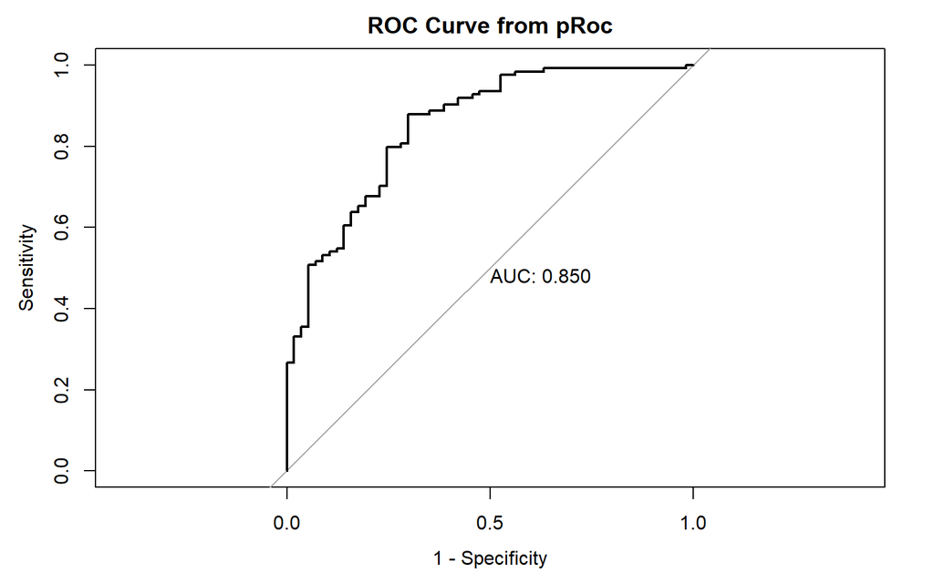

```r
plot(rCurve, main="ROC Curve from pRoc", legacy.axes = TRUE, print.auc=TRUE)
```

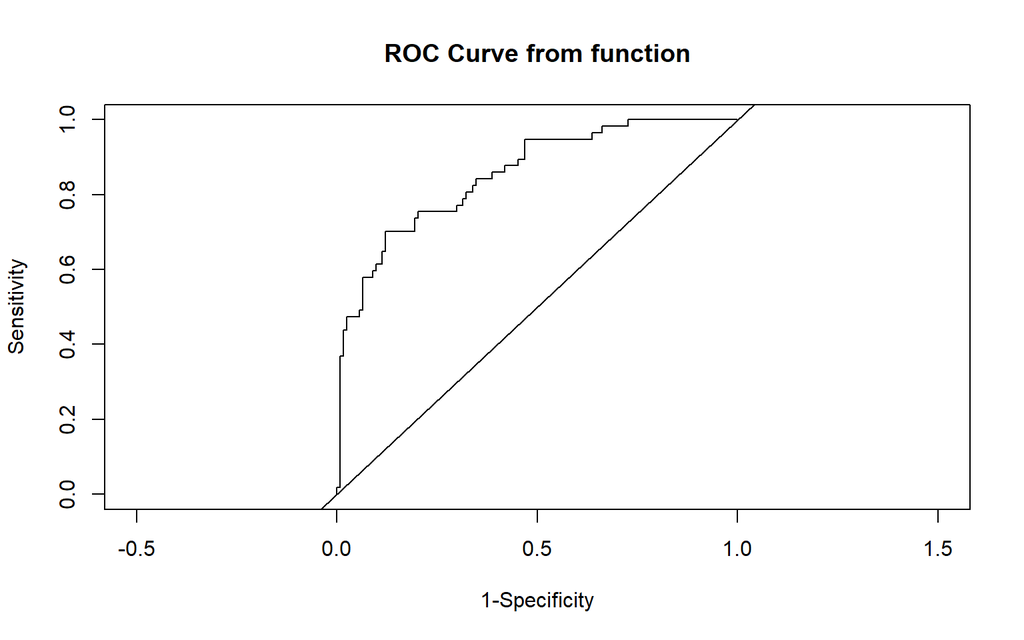

```
## [1] "Area under the curve: 0.843803056027165"
```

```r
Roc_function(data)
```

## References

1. https://www.kaggle.com/kumargh/pimaindiansdiabetescsv
2. https://developers.google.com/machine-learning/crash-course/classification/true-false-positive-negative
3. https://en.wikipedia.org/wiki/Confusion_matrix
4. https://rdrr.io/cran/caret/man/sensitivity.html
5. https://stackoverflow.com/questions/41056896/proc-changing-scale-of-the-roc-chart

## Github link for code

https://github.com/zahirf/Data621/blob/master/HW02/Data621-HW2.Rmd

Marker: 621-02_p